# Gov 50 Final Project

Sophie-An Kingsbury Lee

## Introduction

School is universal, but the quality of schools in the United States vary greatly. Education is considered one of the most important means of building and sustaining a more resilient, efficient society. K-12 schools are at the forefront of this. But, there are huge disparities by race, gender, income, and so on. This study focuses on differences in education outcomes by income, measured by free lunch eligibility. While eligibility requirements for free lunch differ by state, as a whole, the thresholds are adjusted for the different cost of living in each state and thus provide a strong metric of income level. The National’s Score Report assesses fourth, eighth, and twelfth grade math and English proficiency. For this study, the core focus is fourth grade math scores, because math is generally the same from state to state. I am trying to determine what factors influence disparities in test scores by income level, as measured by free lunch eligibility. How do political beliefs affect education disparities between students who do and don’t qualify for free lunch? I hypothesize that states with higher democrat vote percentages experience less inequality between students who don’t qualify for free lunch and students who do, because democratic states have more progressive welfare and education access support. Further, how do youth poverty rates affect differences in test scores? I predict that states with higher youth poverty rates will have higher differences in test scores between students eligible and not eligible for free lunch, because the wealth inequality may translate into education inequality.

## Data

The analyses of this cross-sectional study rely on three data sets. The primary one is [The Nation’s Report Card](https://www.nationsreportcard.gov/) published by the National Assessment of Educational Progress. In particular, the 2022 4th grade mathematics assessment by state and eligibility for free lunch. Each child’s score ranges from 0 to 500 with a national average of 231 points. Qualifying for free lunch in a sense measures the difference in scores by income level. The second data set, percentage of [2020 election votes in support of the Democratic Party](https://electionlab.mit.edu/data) by state, comes from the Massachusetts Institute of Technology Election Data and Science Lab. The percentages are of all voters, not all people eligible to vote. Poverty rates, the final data set, are pulled from the [2020 U.S. Census data](https://data.census.gov/table?q=United+States&t=Poverty&g=0100000US,$0400000&tid=ACSST1Y2021.S1701&tp=true). The poverty percentages are of people aged 5-17, the primary age demographic in schools by state. To calculate the difference in math scores between students who didn’t and did qualify for free lunch, I originally subtracted the average score of students who qualify for free lunch from the average of those who do not to find absolute difference in scores. But, the relative difference in scores better accounts for state to state differences that make the difference in scores seem larger. This is calculated by dividing the absolute score difference by the average score of students not eligible for free lunch.The relative difference in scores accounts for how a 10 point difference in a state with an average score of 271 and a 8 point difference in a state with an average score of 217 are equivalent in the percent difference. Below is the distribution of relative score differences by state as a percentage of scores of students not eligible for free lunch.

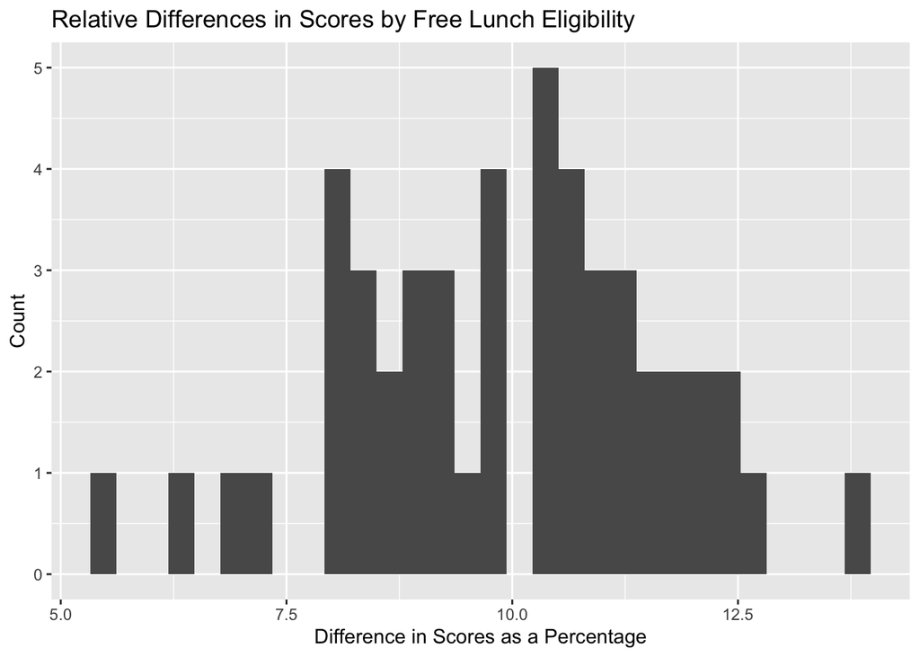

## Results

I plotted both the democrat vote share and poverty rates against the relative score difference by state.

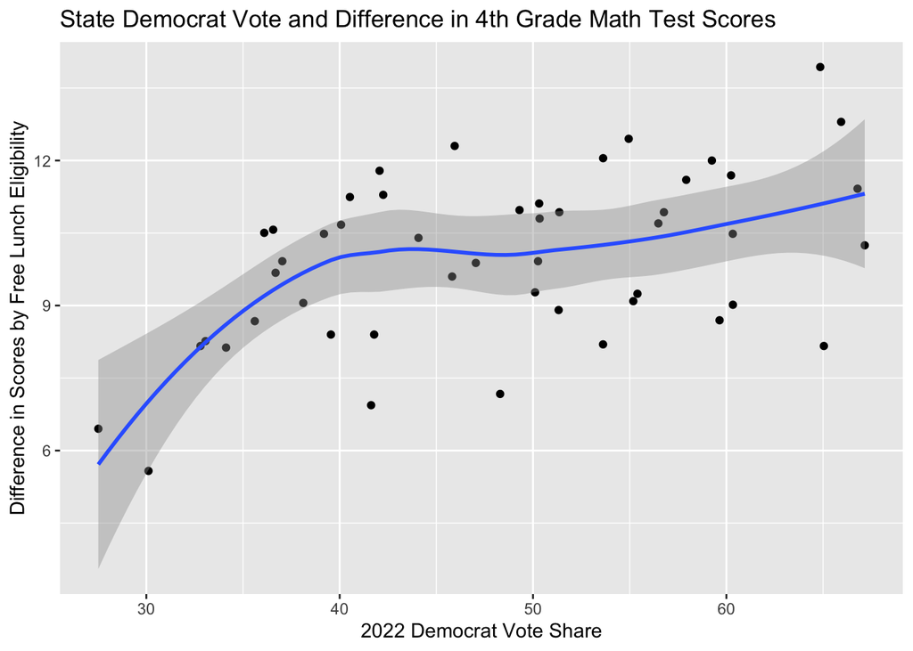

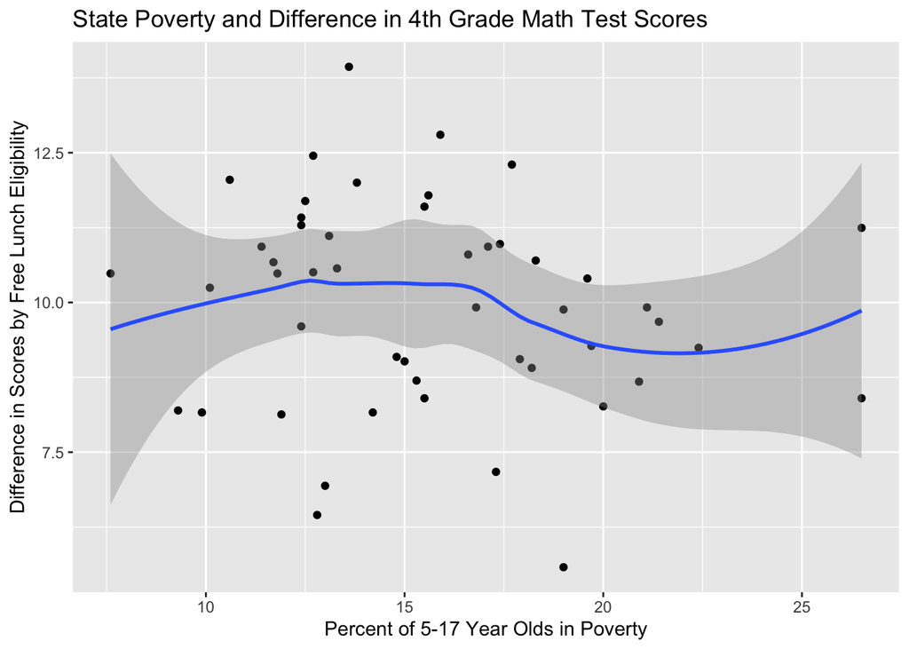

Democrat Votes and Poverty Rates Relationship with Difference in Test Scores

|  | Estimate | Std. Error | t value | Pr(>\|t\|) |
| --- | --- | --- | --- | --- |
| (Intercept) | 6.4635 | 1.5100 | 4.2803 | 0.0001 |
| percent_democrat | 0.0773 | 0.0215 | 3.5931 | 0.0008 |
| poverty | -0.0146 | 0.0550 | -0.2658 | 0.7916 |

Using the relative difference in scores, a one percentage point increase in democratic vote share in the 2020 election is associated with an approximately 0.0773 percentage increase in difference between math test scores for fourth graders who are not eligible for free lunch and those that are. The p-value for this estimate is approximately 0.0008. Using an alpha level of 0.05, we reject the null hypothesis and consider this result statistically significant, because 0.0008 < 0.05. If we assumed the percent of democratic vote share had no impact on differences in math scores, roughly 0.0008 of sampled results would be as or more extreme than the values used in this analysis. Since the p-value is less than 0.05, there is possibly a causal relationship between percent democrat and difference in test scores, but still not for certain. Meanwhile, for a one percentage point increase in poverty rates, we expect a decrease in inequality of test scores by approximately 0.0146 points. The p-value for this result was about 0.7916. At the alpha level of 0.05, this result is not statistically significant and we fail to reject the null hypothesis (that there is no relationship between youth poverty rates and differences in test scores). We cannot prove causation.

Democrat Vote Share and Test Scores for Students Eligible for Free Lunch

|  | Estimate | Std. Error | t value | Pr(>\|t\|) |
| --- | --- | --- | --- | --- |
| (Intercept) | 228.4538 | 3.071 | 74.3915 | 0.0000 |
| percent_democrat | -0.1362 | 0.062 | -2.1973 | 0.0329 |

Democrat Vote Share and Test Scores for Students Not Eligible for Free Lunch

|  | Estimate | Std. Error | t value | Pr(>\|t\|) |
| --- | --- | --- | --- | --- |
| (Intercept) | 243.9974 | 3.2344 | 75.4373 | 0.0000 |
| percent_democrat | 0.0479 | 0.0655 | 0.7306 | 0.4686 |